# Molecular Marker Assisted Plant Breeding

Principal Components and Genetic Relatedness

Felipe Ferrão

University of Florida

**Objectives:**

- 60 minutes of hands-on
- Introduction to PCA and G matrix
- R using different approaches

**Extra information**

- [HOS 6236 – Website](https://lfelipe-ferrao.github.io/class/mas/)
- About the [author](https://lfelipe-ferrao.github.io/)
- About the [UF/IFAS Plant Breeding](https://programs.ifas.ufl.edu/plant-breeding/)

# Introduction

In the previous class, we began exploring GWAS modeling by drawing connections between the models used in GWAS and those used in QTL mapping. One key distinction is the inclusion of a polygenic term and the use of information from principal component analysis (PCA) to account for what we referred to as spurious associations.

In the next classes, we will focus on the main sources of false positives in GWAS analyses and discuss why understanding population structure and relatedness is a crucial step in building reliable GWAS models. However, before we delve into those topics, it is important to first understand two key components of modern GWAS models:

- Principal component analysis (PCA)
- Genetic relatedness.

# Principal Component Analysis (PCA)

PCA is widely used in data science as a technique for linear dimension reduction in high-dimensional data. When working with data that has many features (variables), PCA helps identify the directions—called principal components—that capture the most variance in the data. By projecting the data onto these components, we can reduce the number of features while preserving the most important patterns.

In theory, PCA can be interpreted both geometrically and mathematically, offering intuitive and formal perspectives on how it works.

- Geometrically, PCA finds new axes (principal components) that represent directions of maximum variance in the data, effectively rotating and projecting the original data into a new coordinate system with fewer dimensions. Each principal component is orthogonal (at a right angle) to the others, ensuring that the captured variance is not redundant.
- Mathematically, PCA involves linear algebra operations—most commonly, the eigenvalue decomposition of the covariance matrix or singular value decomposition (SVD) of the data matrix. These approaches identify the eigenvectors (directions) and eigenvalues (amount of variance) that define the principal components. Together, these interpretations help explain how PCA reduces complexity while preserving the most informative structure in the data.

Below one toy example of only two correlated traits (yield and irrigation) and the key steps related to PCA analyses and the intuition behind:

1. **Center the Data**: the entire dataset lies at the origin, and because PCA relies on variance the future PCs will represent directions of maximum spread from a common origin.
2. **Find the Directions of Maximum Variance**: These directions show where the data is most “spread out” and capture the most important patterns in the data.
3. **Orthogonality** : each new principal component is orthogonal (i.e., at a 90° angle) to the previous ones.
4. **Select PCs**: The length (magnitude) of each principal component vector corresponds to the amount of variance it explains. These are sorted from largest to smallest.
5. **Projection**: original data points are projected onto the new axes (PCs), effectively rotating the data.This step transforms the data into a lower-dimensional space for analysis or visualization while preserving the most important variation.

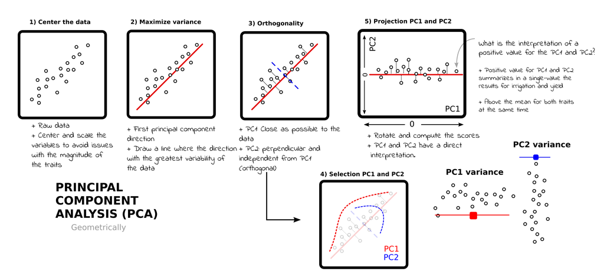

Principal component analysis explained in 5 main steps, by focusing on the geometrical interpretation and implementation. The towy example considers only two correlated traits. In a real scenario, multiple variables and therefore a multidimentional space is considered and summarized in two PCs

## Example using SNP data

Below we present a simple geometrical example where we have two SNPs and simulated genotypes coming from two different populations. Because the populations have very different allele frequency, we will be able to separate both groups only looking the PCA1.

- Population 1 (green)
  - SNP1: 5%
  - SNP2: 95%
- Population 2 (black)
  - SNP1: 95%
  - SNP2: 5%

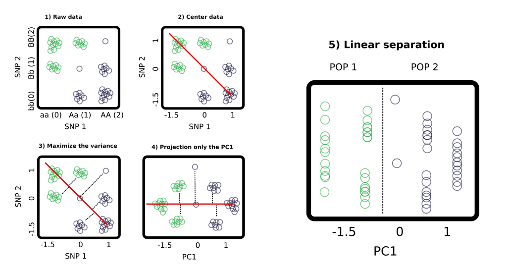

Toy example of Principal component analysis measuring SNP data in two different populations with large difference in allele frequency from two SNPs. Only the PC1 was able to differentiate both populations

## Some mathematical notation

The process begins by considering **X** matrix with the dimension of number of individuals (n) by the number of variables/SNPS (p).

With that, the first step is to centering the data as:
$$\mathbf{X}_{\text{centered}} = \mathbf{X} -
\bar{\mathbf{X}}$$

where ($\bar{\mathbf{X}}$) is the mean of each feature.

In the sequence, we compute the covariance matrix as:

$$\mathbf{C} = \frac{1}{n - 1}
\mathbf{X}_{\text{centered}}^\top
\mathbf{X}_{\text{centered}}$$

PCA then solves the eigenvalue problem:

$$\mathbf{C} \mathbf{v} = \lambda
\mathbf{v},$$
where ($\mathbf{v}$) are the eigenvectors (principal components), and ($\lambda$) are the eigenvalues, representing the variance explained.

The top (k) eigenvectors form a projection matrix ($\mathbf{W}_k$), which is used to transform the data: $\mathbf{Z} = \mathbf{X}_{\text{centered}} \mathbf{W}_k$.

Alternatively, PCA can be performed using Singular Value Decomposition (SVD):

$$\mathbf{X}_{\text{centered}} = \mathbf{U} \boldsymbol{\Sigma}
\mathbf{V}^\top,$$

where the principal components are derived from ($\mathbf{U} \boldsymbol{\Sigma}$), and ($\mathbf{V}$) contains the same directions as the eigenvectors.

# Genetic relatedness

Plants are genetically related to each other, but the level of relatedness varies between pairs of individuals. There are two central concepts related to relatedness:

- **Identical-by-state (IBS)**: Two genomes are IBS at locus j if they have identical DNA sequence at locus j.
- **Identical-by-descent (IBD)**: Two genomes are IBD at locus j, if they have inherited identical DNA sequence at locus j from a common ancestor who has lived at most t generations ago.

In the example below, we will show a simple example on how to use molecular markers to track the IBS and therefore understand the relatedness between individuals. In the toy example below, we have a **M** matrix as individuals by SNPs. The SNPs where scored as -1,0,1 for genotypes that are aa, Aa, AA.

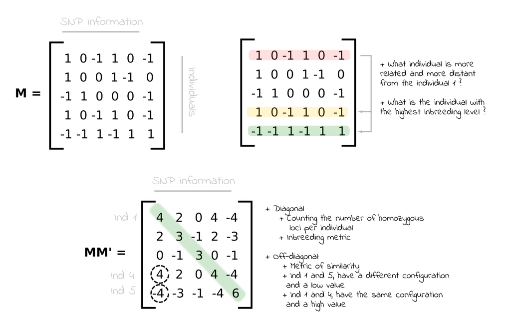

Example of using multiplication matrix to compute genetic relatedness

$$\mathbf{G} = \frac{MM'}{\sum
2p_j(1 - p_j)}$$

where: $p_j$ is the allele frequency of SNP (j).

$$G = \begin{bmatrix}
1 & 0.5 & 0 & 1 & -1 \\
0.5 & 0.75 & -0.25 & 0.5 & -0.75 \\
0 & -0.25 & 0.75 & 0 & -0.25 \\
1 & 0.5 & 0 & 1 & -1 \\
-1 & -0.75 & -0.25 & -1 & 1.5 \\
\end{bmatrix}$$

# Hands-on

## Genetic relatedness using pedigree records

**Background**

- Pedigree-based kinship is calculated from known familial relationships (e.g., parent-offspring, full siblings, etc.), and it assumes a proportion of the genome is shared due to common ancestry—without requiring actual genotype data. This is the definition of **IBD**.
  - Parent-offspring: expected IBD = 0.5
  - Full siblings: expected IBD = 0.5
  - Half siblings: expected IBD = 0.25
  - First cousins: expected IBD = 0.125

**Goals**

- Use the `AGHmatrix` R package
- [Tutorial AGHmatrix](https://cran.r-project.org/web/packages/AGHmatrix/vignettes/Tutorial_AGHmatrix.html)
- For the pedigree presented in the example below, we will input it in `R` and run a pedigree related matrix (also called as **A**) using the `Amatrix` function.
- Plot a heatmap

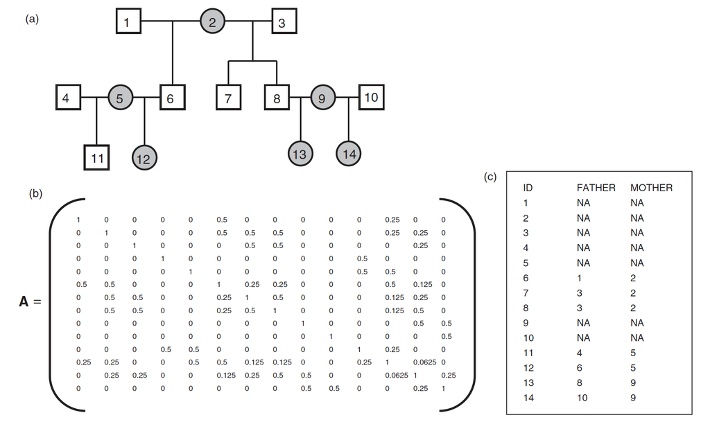

**R codes**

```r
library(AGHmatrix)
# Recording the data
## Important: AGHmatrix record unknown pedigree as 0 (zero) not as NA
ped =data.frame(ID=c(1:14),
           FATHER=c(0,0,0,0,0,1,3,3,0,0,4,6,8,10),
           MOTHER=c(0,0,0,0,0,2,2,2,0,0,5,5,9,9))
ped$ID=as.factor(ped$ID) # Transform into factors
ped$FATHER=as.factor(ped$FATHER)
ped$MOTHER=as.factor(ped$MOTHER)

# Running the package
Aped = Amatrix(ped, ploidy=2)
```

```
## Verifying conflicting data...
## Organizing data...
## Your data was chronologically organized with success.
## Constructing matrix A using ploidy = 2
## Completed! Time = 0  minutes
```

```r
Aped[1:9,1:9]
```

```
##     1   2   3 4 5    6    7    8 9
## 1 1.0 0.0 0.0 0 0 0.50 0.00 0.00 0
## 2 0.0 1.0 0.0 0 0 0.50 0.50 0.50 0
## 3 0.0 0.0 1.0 0 0 0.00 0.50 0.50 0
## 4 0.0 0.0 0.0 1 0 0.00 0.00 0.00 0
## 5 0.0 0.0 0.0 0 1 0.00 0.00 0.00 0
## 6 0.5 0.5 0.0 0 0 1.00 0.25 0.25 0
## 7 0.0 0.5 0.5 0 0 0.25 1.00 0.50 0
## 8 0.0 0.5 0.5 0 0 0.25 0.50 1.00 0
## 9 0.0 0.0 0.0 0 0 0.00 0.00 0.00 1
```

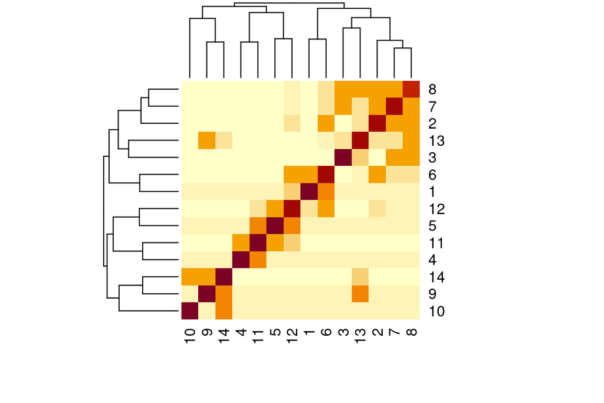

```r
heatmap(Aped)
```

## Genetic relatedness using genomic information

**Data set**

- [Rocha et al., 2025](https://link.springer.com/article/10.1007/s11295-025-01705-w?utm_source=rct_congratemailt&utm_medium=email&utm_campaign=nonoa_20250630&utm_content=10.1007%2Fs11295-025-01705-w). Genomic-assisted selection to guide mate allocation and leverage hybrid vigor in Coffea canephora. Tree Genetics and Genomes. 2025
- 387 Coffea canephora genotypes from a germplasm collection in Brazil, with different origins and phenotypic traits
- Genotypes using capture-seq for a total of 22k SNPs

**Goals**

**R codes for the PCA analysis**

```r
# Data set
load("/home/felipe/Dropbox (UFL)/classes/Molecular_Breeding/class5_GWAS/PCA_Kinship/coffee_example_387ind_22k.Rdata")
K = Gmatrix(X) # G matrix
```

[output not shown]

```r
dim(X); dim(K)
```

```
## [1]   387 22314
```

```
## [1] 387 387
```

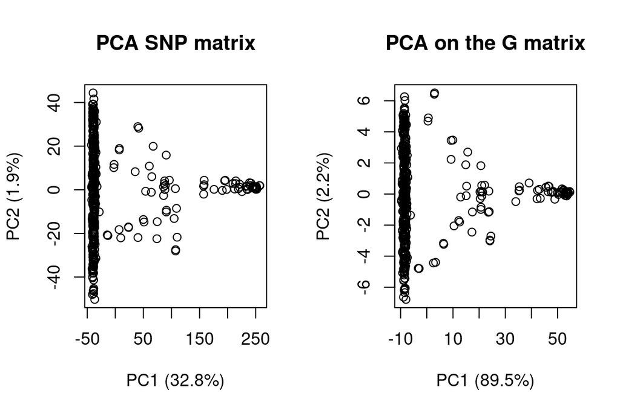

```r
# Run PCA
prc = prcomp(X, center = TRUE, scale = TRUE)
prc1 <- prcomp(K, center = TRUE, scale. = TRUE)

# Ploting the pca structure
par(mfrow=c(1,2))
# Calculate proportion of variance explained
explained_var <- (prc$sdev)^2 / sum(prc$sdev^2)
explained_var_pc1 <- round(100 * explained_var[1], 1)
explained_var_pc2 <- round(100 * explained_var[2], 1)

# Plot PC1 vs PC2 with % explained
plot(prc$x[,1], prc$x[,2],
     xlab = paste0("PC1 (", explained_var_pc1, "%)"),
     ylab = paste0("PC2 (", explained_var_pc2, "%)"),
     main = "PCA SNP matrix")

# Calculate proportion of variance explained
explained_var <- (prc1$sdev)^2 / sum(prc1$sdev^2)
explained_var_pc1 <- round(100 * explained_var[1], 1)
explained_var_pc2 <- round(100 * explained_var[2], 1)

# Plot PC1 vs PC2 with % explained
plot(prc1$x[,1], prc1$x[,2],
     xlab = paste0("PC1 (", explained_var_pc1, "%)"),
     ylab = paste0("PC2 (", explained_var_pc2, "%)"),
     main = "PCA on the G matrix")
```

**Comments**

- Results using the raw SNP data and the G matrix are very similar and could capture the same story.
- Coffee data set is divided into two main groups:
  - Conilon botanical group at the left hand of the plot, that contains more individuals.
  - Robusta bontanical group at the right hand of the plot, that is less present in the Brazilian germplasm
  - Individuals in the middle of both groups are hybrids between both botanical groups.
- Analysis using the G matrix are faster, because it is a matrix with a lower dimension (n x n).
- Dimension also reflected on the proportion of variance explained by each approach. The lower dimension presented in the G matrix retained a larger percentage of the variance.

**Looking the G matrix**

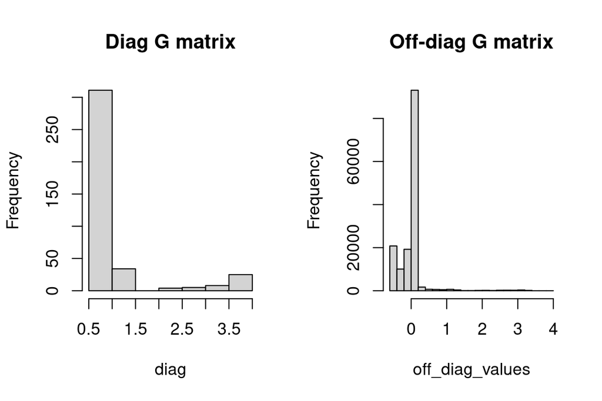

```r
par(mfrow=c(1,2))
diag = diag(K)
off_diag_values = K[lower.tri(K, diag = FALSE) | upper.tri(K, diag = FALSE)]
hist(diag, main= "Diag G matrix")
hist(off_diag_values, main="Off-diag G matrix")
```

- In a VanRaden G matrix, diagonal elements represent self-relatedness (akin to inbreeding coefficients), while off-diagonal elements represent pairwise relatedness between different individuals.
- What causes diagonal values > 1 (inflated values)?
  - Inbreeding or/and strong population stratification.
  - But *C. canephora* is self-incompatible !
  - Population structure is basically creating inflated values. When we center the SNP matrix by overall allele frequencies, individuals from a genetically distinct subpopulation can appear more related to themselves than to the rest of the population.

**Breaking the original population into sub-populations**

- Based on the PCA analysis, we separed both populations
- We excluded the hybrids from the analysis
- Run a **G** matrix for Robusta and Conilon
- Diagonal and off-diagonal analysis per group

```r
# Separating the subpopulations
conilon = prc1$x[,1]<(-1)
robusta = prc1$x[,1]>30

X_conilon = X[names(conilon[conilon==T]),]
X_robusta = X[names(robusta[robusta==T]),]

K_conilon = Gmatrix(X_conilon) # G matrix for the robusta group
```

[output not shown]

```r
K_robusta = Gmatrix(X_robusta) # G matrix for the conilon group
```

[output not shown]

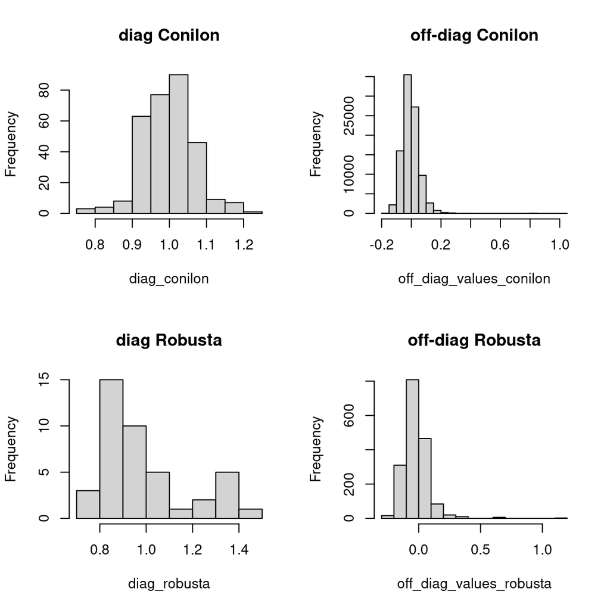

```r
par(mfrow=c(2,2))
diag_conilon = diag(K_conilon)
off_diag_values_conilon = K_conilon[lower.tri(K_conilon, diag = FALSE) | upper.tri(K_conilon, diag = FALSE)]
hist(diag_conilon,main="diag Conilon")
hist(off_diag_values_conilon,main="off-diag Conilon")

diag_robusta = diag(K_robusta)
off_diag_values_robusta = K_robusta[lower.tri(K_robusta, diag = FALSE) | upper.tri(K_robusta, diag = FALSE)]
hist(diag_robusta,main="diag Robusta")
hist(off_diag_values_robusta,main="off-diag Robusta")
```

**Comments**

- Diagonal of the matrix is more aligned to the expected values.
- Large values in the off-diagonal means some duplicated samples included in the genotyping for internal control

**PCA only for the conilon samples**

- Runing the PCA analysis only for the conilon group

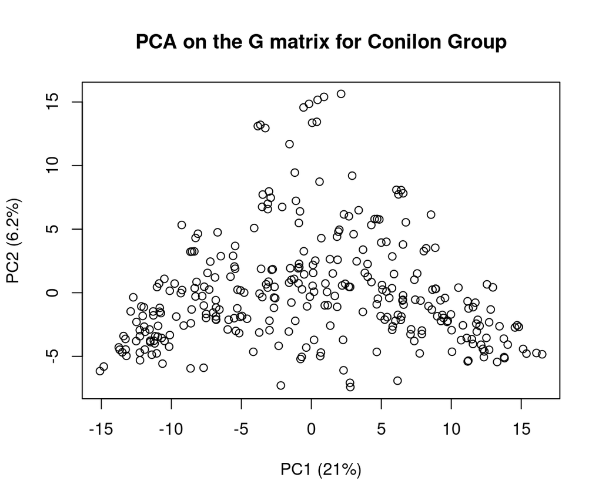

```r
# Conilon PCA
prc_conilon = prcomp(K_conilon, center = TRUE, scale = TRUE)
# Calculate proportion of variance explained
explained_var <- (prc_conilon$sdev)^2 / sum(prc_conilon$sdev^2)
explained_var_pc1 <- round(100 * explained_var[1], 1)
explained_var_pc2 <- round(100 * explained_var[2], 1)

# Plot PC1 vs PC2 with % explained
plot(prc_conilon$x[,1], prc_conilon$x[,2],
     xlab = paste0("PC1 (", explained_var_pc1, "%)"),
     ylab = paste0("PC2 (", explained_var_pc2, "%)"),
     main = "PCA on the G matrix for Conilon Group")
```

**Comments**

- No clear population structure
- We can see some differences in minor magnitude within the group

# Conclusions

The PCA and the genomic relationship matrix (G matrix) are complementary tools in genomic analysis.

PCA is primarily used to explore and correct for population structure. By reducing the dimensionality of genomic data, PCA captures the major axes of genetic variation, allowing researchers to control for structure or visualize relatedness among individuals. The G matrix, particularly when constructed using VanRaden’s method, quantifies genomic relationships and self-relatedness based on allele sharing. The diagonal values indicate the genomic inbreeding of individuals, while off-diagonal values reflect their pairwise genomic similarity.

# References

- James, G., Witten, D., Hastie, T., & Tibshirani, R. (2021). An Introduction to Statistical Learning: With Applications in R (2nd ed.). Springer.
- Rocha et al., 2025. Genomic-assisted selection to guide mate allocation and leverage hybrid vigor in Coffea canephora. Tree Genetics and Genomes. 2025
- VanRaden, P. M. (2008). Efficient methods to compute genomic predictions. Journal of Dairy Science, 91(11), 4414–4423